# Genome-wide analysis of mutation load in Capybara genome

Santiago Herrera-Alvarez

September 9, 2018

```r
library(ggplot2)
library(Rmisc)
library(cowplot)
library(phytools)
library(geiger)
library(biomaRt)
library(dplyr)
library(ggpubr)
library(ggrepel)
```

### Analysis of $d_N/d_S$ ($\omega$) values accross rodent genomes

### Density plot of the distribution of $\omega$ values for each species:

As can be seen, the capybara clearly has a bimodal distribution on $\omega$ values.

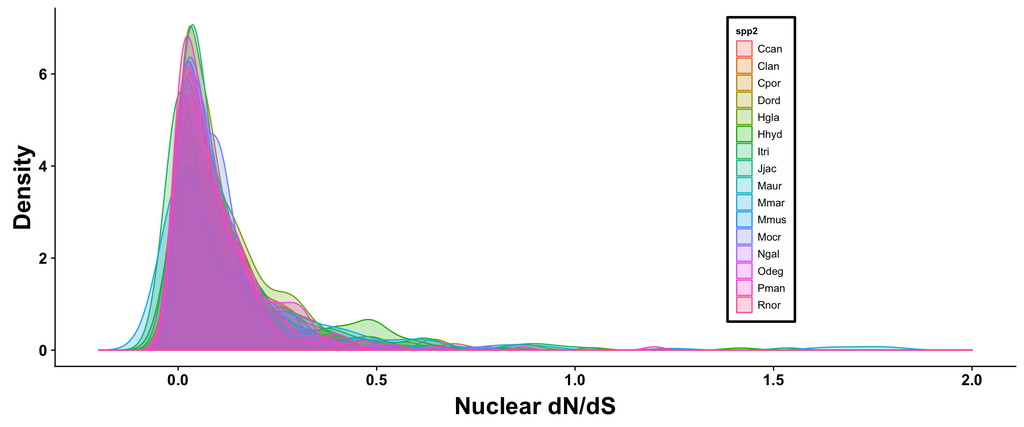

### Density plot of the distribution of $\omega$ values per group

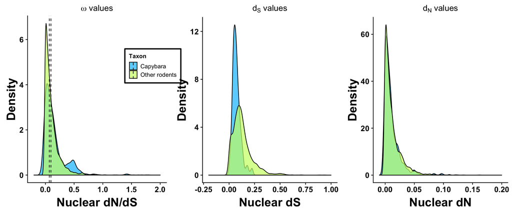

## Permutation (Monte Carlo) Test

```r
## Permutation test 1: dN/dS
n=10000
wT=c(wC,wR)
null_dist=NULL
for (i in 1:n) {
  remuestreo_cap=sample(wT,length(wC),replace=T)
  medianC=median(remuestreo_cap)
  remuestreo_rod=sample(wT,length(wR),replace=T)
  medianR=median(remuestreo_rod)
  diff=medianC-medianR
  null_dist=c(null_dist,diff)
}

diff_real <- median(wC)-median(wR)

pval <- sum(null_dist>=diff_real)/n
print(paste("P-value for dN/dS difference: ",pval))

## Permutation test 2: dS
n=10000
dsT=c(dsC,dsR)
null_dist_ds=NULL
for (i in 1:n) {
  remuestreo_cap=sample(dsT,length(dsC),replace=T)
  medianC=median(remuestreo_cap)
  remuestreo_rod=sample(dsT,length(dsR),replace=T)
  medianR=median(remuestreo_rod)
  diff=medianC-medianR
  null_dist_ds=c(null_dist_ds,diff)
}

diff_real_ds <- median(dsC)-median(dsR)

pval_ds <- sum(null_dist_ds<=diff_real_ds)/n
print(paste("P-value for dS difference: ",pval_ds))

## Permutation test 3: dN
n=10000
dnT=c(dnC,dnR)
null_dist_dn=NULL
for (i in 1:n) {
  remuestreo_cap=sample(dnT,length(dnC),replace=T)
  medianC=median(remuestreo_cap)
  remuestreo_rod=sample(dnT,length(dnR),replace=T)
  medianR=median(remuestreo_rod)
  diff=medianC-medianR
  null_dist_dn=c(null_dist_dn,diff)
}

diff_real_dn <- median(dnC)-median(dnR)

pval_dn <- sum(null_dist_dn<=diff_real_dn)/n
print(paste("P-value for dN difference: ",pval_dn))
```

```
# [1] "P-value for dN/dS difference:  6e-04"
# [1] "P-value for dS difference:  0"
# [1] "P-value for dN difference:  0.2519"
```

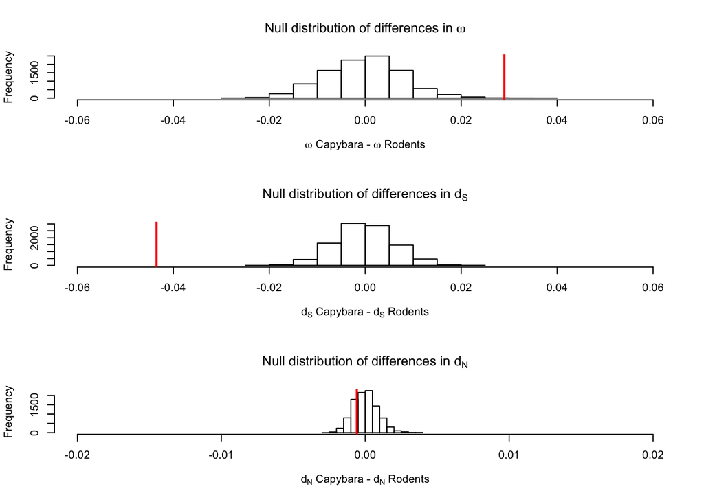

Median values for each substitution rate class

[output not shown]

## Bootstrap analysis:

Re-sampling of $\omega$ values per group (Capybara vs. Other rodents) and comparison of mean $\omega$ values between both groups.

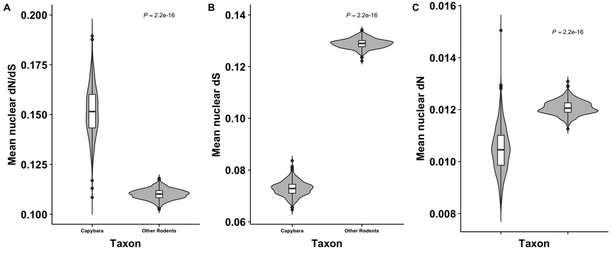

Although this time the difference in mean $d_N$ values is significant, is clearly less dramatic than the difference between mean $d_S$ values, suggesting again that the higher mean $\omega$ value in the capybara is driven by a low $d_S$.

These analyses clearly suggest that the higher mean $\omega$ value observed in the capybara is mainly due to a low synonymous substitution rate relative to the rest of rodents. Using the synonymous substitution rate as a surrogate for the mutation rate, and acknowledging the negative relationship between mutation rate and generation time, the higher mean $\omega$ value in the capybara is compatible with a reduction in population size due to a longer generation time caused by an increase in body size.

## Body mass and generation time explain mean $\omega$

We performed a correlation of the mean $\omega$ values observed in each species with the body mass and generation time, to understand how body mass affects genome evolution, particularly, the accumulation of slightly deleterious mutations.

To control by the potential counfunding effect of shared ancestry, we performed Phylogenetic Independet Constrasts (PIC; Felsenstein, 1985).

We also checked for outliers, and identified that genome-wide median $\omega$ values for naked mole rat and squirrel were too high and low, respectively, according to a standardized residual analysis (see boxplots). Given that there seems to be a biologically reasonable (and different) explanation for the inflation in $\omega$ in the naked mole rat, we decided not to take that value as part for downstream analyses (see also AIC values comparing the model fitting between a model with (mod.a) and without (mod.a2) the naked mole rat data point).

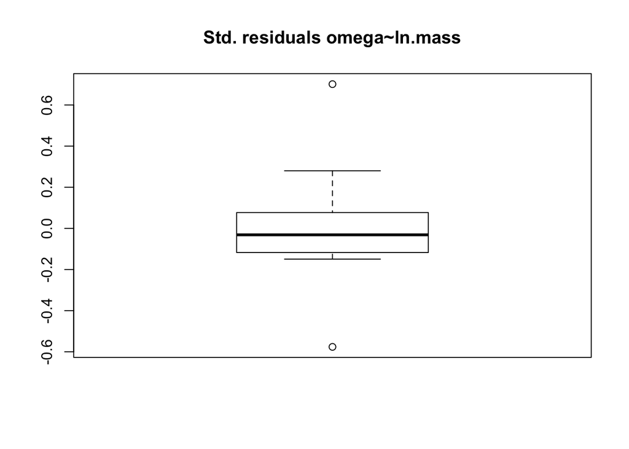

```r
#Body mass values - data in grams
#Generation times values extracted from AnAge database - data in days (BMRat value estimated from european mole rat).
tr <- read.tree("../OrthoMaM_370-SCOs_17genomes_RAxML.tre")
tab <- read.csv("../omegaNuc_vs_bodyMass.csv",row.names=2)
omega<-setNames(tab$median_omega,rownames(tab))

#PIC's body mass and nuclear dN/dS
ln.mass <- setNames(tab$ln.masa,rownames(tab))
tr.masaOmega<-drop.tip(tr,name.check(tr,omega)$tree_not_data)
IC.logMass<-pic(ln.mass,tr.masaOmega)
IC.Omega<-pic(omega,tr.masaOmega)

mod.a <- lm(IC.Omega~IC.logMass)
summary(mod.a)

#PIC's generation time and nuclear dN/dS
tab$ln.gen_time <- log(tab$gen.time_days)
ln.GT <- setNames(tab$ln.gen_time,rownames(tab))
tr.GTomega<-drop.tip(tr,name.check(tr,omega)$tree_not_data)
IC.logGT<-pic(ln.GT,tr.GTomega)
IC.Omega<-pic(omega,tr.GTomega)

mod.b <- lm(IC.Omega~IC.logGT)
summary(mod.b)

#Correlation body mass and generation time
cor.test(IC.logMass,IC.logGT, method="spearman")

#Interaction between BM and GT explaining variation in dN/dS
tab$ln.GTxBM <- log(tab$masa_gr*tab$gen.time)
ln.GTxBM <- setNames(tab$ln.GTxBM,rownames(tab))
tr.masaOmega<-drop.tip(tr,name.check(tr,omega)$tree_not_data)
IC.logGTxBM<-pic(ln.GTxBM,tr.masaOmega)
mod.c <- lm(IC.Omega~IC.logGTxBM)

  ## Standardized residuals analysis to detect outliers: Naked moles rat and squirrel omega values are outliers.
reg1 <- lm(omega~ln.mass) #model with body mass
leverage1 <- hat(model.matrix(reg1)) #Find leverage for each residual
se <- function(x){sd(x)/sqrt(length(x))} # Standard error of the mean
# Standardized residuals: res_i/sqrt(MSE(1-leverage))
st_res1 <- reg1$residuals/(sqrt(se(reg1$residuals)*(1-leverage1)))
boxplot(st_res1,main="Std. residuals omega~ln.mass")
```

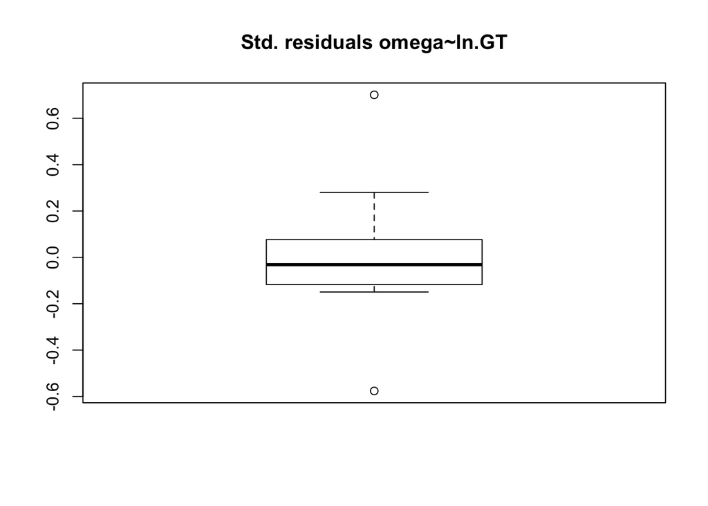

```r
reg2 <- lm(omega~ln.mass) #model with generation time
leverage2 <- hat(model.matrix(reg2))
st_res2 <- reg2$residuals/(sqrt(se(reg2$residuals)*(1-leverage2)))
boxplot(st_res2,main="Std. residuals omega~ln.GT")
```

```r
  ##Analysis without naked mole rat
## 1) Body mass and omega
tr2.masa <- drop.tip(tr.masaOmega,"NMRat")
tab2 <- tab[-16,]
omega2<-setNames(tab2$median_omega,rownames(tab2))
ln.mass2 <- setNames(tab2$ln.masa,rownames(tab2))
IC.logMass2<-pic(ln.mass2,tr2.masa)
IC.Omega2<-pic(omega2,tr2.masa)

mod.a2 <- lm(IC.Omega2~IC.logMass2)
summary(mod.a2)

##2) Gen. time and omega
tr2.gt <- drop.tip(tr.GTomega,"NMRat")
tab2 <- tab[-16,]
omega2<-setNames(tab2$median_omega,rownames(tab2))
ln.GT2 <- setNames(tab2$ln.gen_time,rownames(tab2))
IC.logGT2<-pic(ln.GT2,tr2.gt)
IC.Omega2<-pic(omega2,tr2.gt)

mod.b2 <- lm(IC.Omega2~IC.logGT2)
summary(mod.b2)

# Comparison between models: Excluding the naked mole rat increases the Likelihood of the model.
AIC(mod.a,mod.a2,mod.b,mod.b2,mod.c)

#library(gvlma)
#Assessment of linear model assumptions
#g <- gvlma(mod)
#summary(g)
```

[output not shown]

[output cut: 30 more lines]

```
#
# Residuals:
#       Min        1Q    Median        3Q       Max
# -0.138394 -0.029979  0.002076  0.031257  0.082377
#
# Coefficients:
#              Estimate Std. Error t value Pr(>|t|)
# (Intercept) -0.025728   0.016091  -1.599   0.1358
# IC.logGT2    0.011745   0.004413   2.662   0.0207 *
# ---
# Signif. codes:  0 '***' 0.001 '**' 0.01 '*' 0.05 '.' 0.1 ' ' 1
#
# Residual standard error: 0.06005 on 12 degrees of freedom
# Multiple R-squared:  0.3712,  Adjusted R-squared:  0.3188
# F-statistic: 7.085 on 1 and 12 DF,  p-value: 0.02072
```

|  | df | AIC |
| --- | --- | --- |
| mod.a | 3 | -36.71817 |
| mod.a2 | 3 | -41.40977 |
| mod.b | 3 | -36.46561 |
| mod.b2 | 3 | -35.18039 |
| mod.c | 3 | -37.38074 |

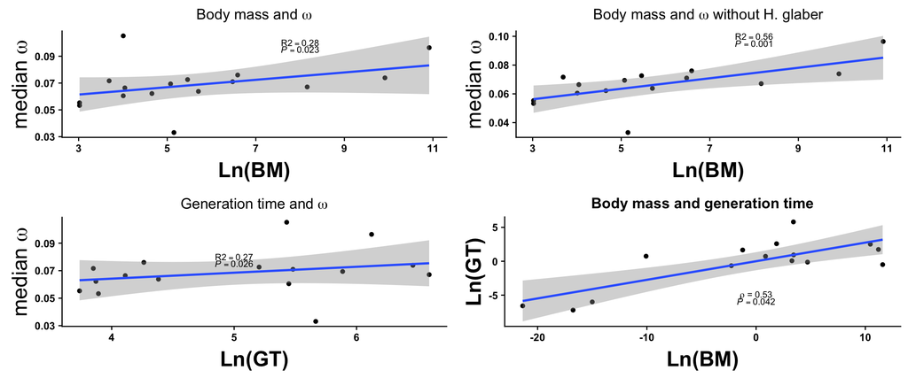

The elevated $\omega$ in the capybara seems to still be compatible with the assumption of mutation load caused by higher genetic drift relative purifying selection: the capybara seems to have comparatively a higher number of fixed nearly deleterious mutations despite a lower synonymous substitution rate. Interestingly, however, the effect might be driven by the longer generation time (correlated to the size) which causes an overall lower $d_S$.

### Heatmap of $\omega$ values for mitochondrial genes

The following heatmap shows the standardized (z-score) $\omega$ values for the 13 protein-coding mitochondrial genes of 10 rodents. Visually, it appears to be two groups based on the $\omega$ values: one group with ‘high’ mt-genome-wide $\omega$ corresponding to hystricognath rodents, and another group with ‘low’ mt-genome-wide $\omega$ with the remaining species.

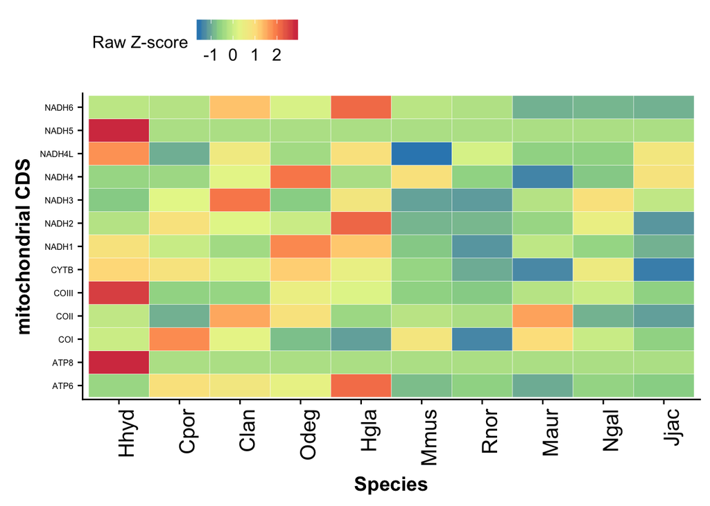

## Nuclear $\omega$ and mitochondrial $\omega$

To corroborate that the mutation load was caused by a demographic effect, we plotted the nuclear genome-wide median $\omega$, i.e., $nuc_\omega$ vs. the mitochondrial genome-wide median $\omega$, i.e., $mt_\omega$, for each species for which both genome were available. We tested the hypothesis that under demographic bottlenecks, drift should affect both genomes (Piganeau & Eyre-Walker, 2009). According to this hypothesis, we expected that the capybara and the naked mole rat, which independently evolved towards a lower Ne, driven by an increased body size and fossoriality-eusociality, respectively, should present higher $\omega$ values in both genomes, relative to the rest of rodents. Consistent with this, both species showed genome-wide median $\omega$ values, for both genomes, above the mean for the entire clade, suggesting that both species suffered a reduction in Ne.

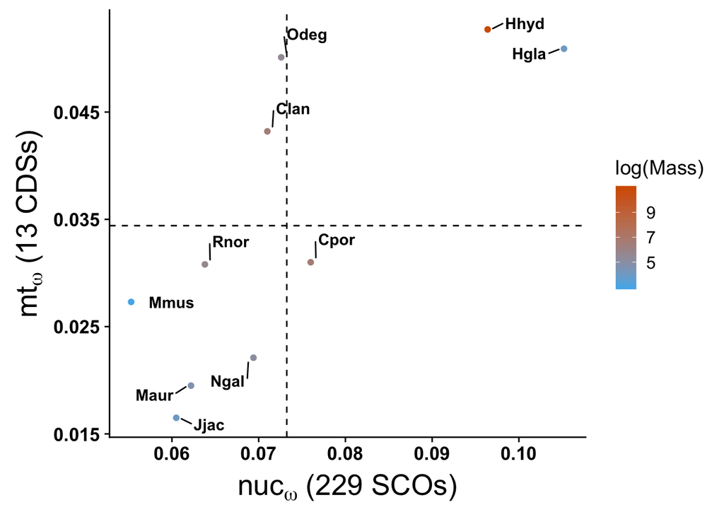

```r
omega_mt_nuc <- read.csv("../omegaMt_Nuc_vs_bodyMass.csv",row.names=2)

ggplot(omega_mt_nuc, aes(x = median_nuc_w, y = median_mt_w, color=ln.masa)) +
  geom_point() + xlab(expression(paste("nuc"[omega], " (229 SCOs)"))) + ylab(expression(paste("mt"[omega]," (13 CDSs)"))) + theme(panel.background = element_rect(fill = "white", colour = "black"), panel.grid.major = element_blank(), panel.grid.minor = element_blank(), axis.text.x = element_text(face="bold", size=13),axis.text.y = element_text(face="bold", size=13), axis.title.y = element_text(face="bold", size=20),axis.title.x = element_text(face="bold", size=20)) +
  geom_vline(data=omega_mt_nuc,aes(xintercept=mean(omega_mt_nuc$median_nuc_w)),linetype="dashed") +
  geom_hline(data=omega_mt_nuc,aes(yintercept=mean(omega_mt_nuc$median_mt_w)),linetype="dashed") +
  geom_text_repel(data=omega_mt_nuc,aes(label=sp),fontface = 'bold', color = 'black', box.padding = unit(0.35, "lines"), point.padding = unit(0.5, "lines")) +
  scale_color_gradient(low="#56B4E9", high="#D55E00") + labs(color="log(Mass)")
```

The correlation between nuclear and mitochondrial $\omega$ values across species was estimated, under the hypothesis that a demographic bottleneck should affect both genomes. Consistent with this, there is a possitive correlation, even when the capybara and the naked mole rat are excluded.

```r
omega_mt_nuc2 <- omega_mt_nuc %>% filter(sp != "Hgla") %>% filter(sp != "Hhyd")

cor.test(omega_mt_nuc$median_nuc_w,omega_mt_nuc$median_mt_w,method="spearman")
cor.test(omega_mt_nuc2$median_nuc_w,omega_mt_nuc2$median_mt_w,method="spearman")
```

```
#
#   Spearman's rank correlation rho
#
# data:  omega_mt_nuc$median_nuc_w and omega_mt_nuc$median_mt_w
# S = 24, p-value = 0.003505
# alternative hypothesis: true rho is not equal to 0
# sample estimates:
#       rho
# 0.8545455
#
#
#   Spearman's rank correlation rho
#
# data:  omega_mt_nuc2$median_nuc_w and omega_mt_nuc2$median_mt_w
# S = 22, p-value = 0.04583
# alternative hypothesis: true rho is not equal to 0
# sample estimates:
#       rho
# 0.7380952
```

## ‘Dissection’ of the second peak in the capybara

The distribution of $d_N/d_S$ values in the capybara is bimodal, with one peak close to the mean of the rest of rodents, and the other peak at ~0.5. To understand the processes underlying the appearance of the second peak, we extracted genes with $d_N/d_S$ >= 0.35 (dashed line; where the second peak starts), resulting in 33 genes.

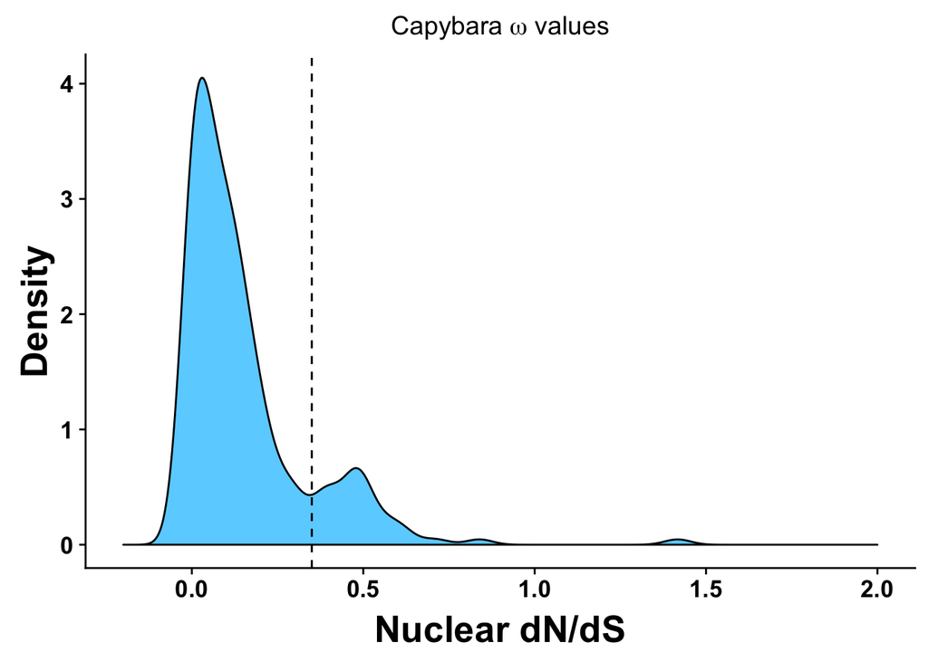

```r
##GO enrichment analysis using Guinea pig Ensembl protein IDs with biomaRt
outdat <- read.table("../omega_values.txt",h=TRUE)
outliers <- outdat[outdat$Capybara>=0.35 & outdat$Capybara<=2,]
outliers_accnum <- outliers$Cavpor_AccNumber
todos_accnum <- outdat$Cavpor_AccNumber

ensembl=useMart("ensembl")
cpor_ensembl <-  useMart("ensembl", dataset = "cporcellus_gene_ensembl")
out = getBM(attributes = c("ensembl_peptide_id","external_gene_name","go_id","goslim_goa_description","percentage_gene_gc_content"), filters="refseq_mrna_predicted", values = as.character(outliers_accnum), mart = cpor_ensembl)
all = getBM(attributes = c("ensembl_peptide_id","external_gene_name","go_id","goslim_goa_description","percentage_gene_gc_content","refseq_mrna_predicted"), filters="refseq_mrna_predicted", values = as.character(todos_accnum), mart = cpor_ensembl)

all_GOs <- all$goslim_goa_description
out_GOs <- out$goslim_goa_description
unique_out_GOs <- unique(out$goslim_goa_description)
fisherPvalues_out <- c()
GO_term <- c()

for(i in 1:length(unique_out_GOs)){
  a <- sapply(unique_out_GOs[i],function(x) sum(x==out_GOs))
  b <- sapply(unique_out_GOs[i],function(x) sum(x==all_GOs))
  c <- length(out_GOs)-a
  d <- length(all_GOs)-b
  f <- fisher.test(matrix(c(a,b,c,d),nrow=2,ncol=2,byrow=TRUE),alternative="greater")
  GO_term <- c(GO_term,as.character(unique_out_GOs[i]))
  fisherPvalues_out <- c(fisherPvalues_out,f$p.value)
}
fisherPvalues_out_Bonferroni <- p.adjust(fisherPvalues_out,method="bonferroni",n=length(fisherPvalues_out))
out_fisherResults <- data.frame(GO_term,fisherPvalues_out,fisherPvalues_out_Bonferroni)
significativas_out <- out_fisherResults[out_fisherResults$fisherPvalues_out_Bonferroni<0.05,]
significativas_out
```

|  | GO_term | fisherPvalues_out | fisherPvalues_out_Bonferroni |
| --- | --- | --- | --- |
| 1 | biological_process | 1.350951e-06 | 8.240800e-05 |
| 5 | cellular_component | 3.701781e-07 | 2.258087e-05 |
| 6 | cell | 7.554402e-07 | 4.608185e-05 |
| 9 | cytoplasm | 7.969269e-05 | 4.861254e-03 |
| 11 | mitochondrion | 2.686371e-11 | 1.638686e-09 |
| 13 | molecular_function | 6.140305e-06 | 3.745586e-04 |
| 14 | RNA binding | 6.168577e-07 | 3.762832e-05 |
| 15 | mRNA processing | 5.572843e-05 | 3.399434e-03 |
| 17 | oxidoreductase activity | 2.502133e-07 | 1.526301e-05 |
| 18 | mitochondrion organization | 1.245617e-05 | 7.598264e-04 |

[output cut: 11 more lines]

```r
capybara_w <- outdat %>% dplyr::select(Hhyd_Code,Capybara) %>% mutate(capybara_w = Capybara) %>% dplyr::select(Hhyd_Code,capybara_w)
dsTab <- read.table("../dS_values.txt",h=TRUE) %>% dplyr::select(Hhyd_Code,Capybara) %>% mutate(capybara_ds = Capybara) %>% dplyr::select(Hhyd_Code,capybara_ds)
dnTab <- read.table("../dN_values.txt",h=TRUE) %>% dplyr::select(Hhyd_Code,Capybara) %>% mutate(capybara_dn = Capybara) %>% dplyr::select(Hhyd_Code,capybara_dn)

totalTab <- inner_join(dsTab, dnTab,  by = "Hhyd_Code")
totalTab <- inner_join(totalTab, capybara_w,  by = "Hhyd_Code")

#Extracting genes from each peak
lowdnds <- outdat[outdat$Capybara<0.35,]
lowdnds_accnum <- lowdnds$Hhyd_Code
highdnds <- outdat[outdat$Capybara>=0.35 & outdat$Capybara<=2,]
highdnds_accnum <- highdnds$Hhyd_Code
w_filt_lowdnds <- subset(totalTab,Hhyd_Code %in% lowdnds_accnum)
w_filt_highdnds <- subset(totalTab,Hhyd_Code %in% highdnds_accnum)

#Comparison of dS and dN between peaks
t.test(w_filt_lowdnds$capybara_ds,w_filt_highdnds$capybara_ds)
t.test(w_filt_lowdnds$capybara_dn,w_filt_highdnds$capybara_dn)
```

```
#
#   Welch Two Sample t-test
#
# data:  w_filt_lowdnds$capybara_ds and w_filt_highdnds$capybara_ds
# t = 2.1556, df = 52.81, p-value = 0.03569
# alternative hypothesis: true difference in means is not equal to 0
# 95 percent confidence interval:
#  0.0009267805 0.0257654550
# sample estimates:
#  mean of x  mean of y
# 0.07502066 0.06167455
#
#
#   Welch Two Sample t-test
#
# data:  w_filt_lowdnds$capybara_dn and w_filt_highdnds$capybara_dn
# t = -7.1872, df = 33.31, p-value = 2.916e-08
# alternative hypothesis: true difference in means is not equal to 0
# 95 percent confidence interval:
#  -0.03236592 -0.01808858
# sample estimates:
#   mean of x   mean of y
# 0.006629446 0.031856697
```

To evaluate additional factors, other than a potential adaptive shift, that could explain the bimodal distribution of genome-wide $\omega$ in the capybara, we focused on GC composition (%GC). Interestingly, the figure below shows that GC content of the genes to the left of the dashed line (low-$\omega$ genes) is higher than that of the genes to the right of the dashed line (high-$\omega$ genes).

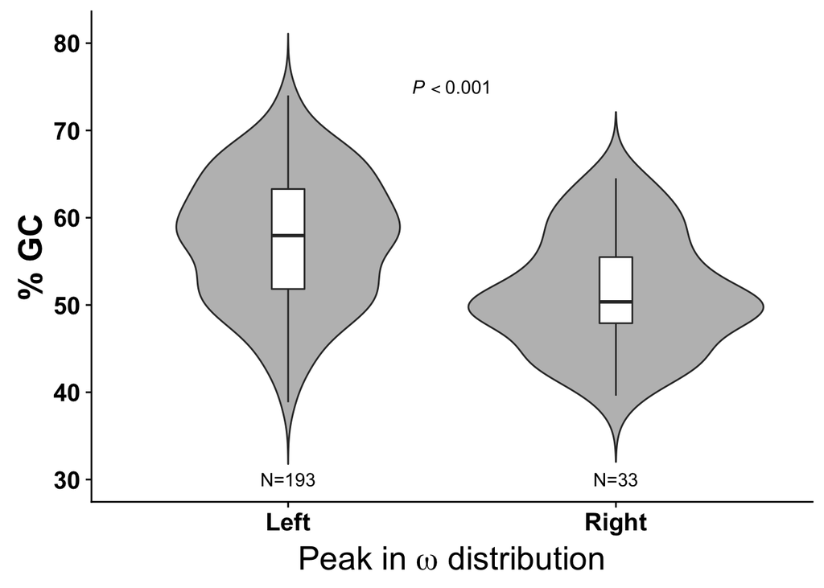

```
#
#   Welch Two Sample t-test
#
# data:  gc_filt_lowdnds$GC_content_total and gc_filt_highdnds$GC_content_total
# t = 4.8881, df = 47.61, p-value = 1.197e-05
# alternative hypothesis: true difference in means is not equal to 0
# 95 percent confidence interval:
#  3.627981 8.699884
# sample estimates:
# mean of x mean of y
#  57.52632  51.36238
```

```r
gc_tbl <- read.table("../GC_content_capybara.txt",h=TRUE)
gc_filt_lowdnds <- subset(gc_tbl,Hhyd_Code %in% lowdnds_accnum)
gc_filt_highdnds <- subset(gc_tbl,Hhyd_Code %in% highdnds_accnum)

gc <- c(gc_filt_lowdnds$GC_content_total,gc_filt_highdnds$GC_content_total)
gene_class <- c(rep("Left",length(gc_filt_lowdnds$GC_content_total)),rep("Right",length(gc_filt_highdnds$GC_content_total)))
gc_table <- data.frame(gene_class,gc)

t.test(gc_filt_lowdnds$GC_content_total,gc_filt_highdnds$GC_content_total)

ggplot(gc_table, aes(x=gene_class, y=gc)) + geom_violin(trim=FALSE,fill="gray") + geom_boxplot(width=0.1) +
  xlab(expression(paste("Peak in ",omega," distribution"))) +
  ylab("% GC") +
  theme(panel.background = element_rect(fill = "white", colour = "black"), panel.grid.major = element_blank(), panel.grid.minor = element_blank(), axis.text.x = element_text(face="bold", size=15),axis.text.y = element_text(face="bold", size=15), axis.title.y = element_text(face="bold", size=20),axis.title.x = element_text(face="bold", size=20)) + annotate("text",x=1.5,y=75,label="italic(P) < 0.001",parse=TRUE,size=4,fontface=2) + annotate("text",x=1,y=30,label="N=193",size=4,fontface=1) + annotate("text",x=2,y=30,label="N=33",size=4,fontface=1)
```

> - Mean %GC high-$\omega$ genes: 51.362 (N=33)
> - Mean %GC low-$\omega$ genes: 57.526 (N=193)
> - p-value < 0.0001

The figure below shows the correlation between GC content and each substitution rate class in the capybara. GC content is weakly positively correlated with $d_S$ and weakly negatively correlated with $d_N$. This results in genes with lower GC content having higher $\omega$ relative to the genes with high GC content, corroborating the observations outlined above.

```r
totalTab <- inner_join(totalTab, gc_tbl,  by = "Hhyd_Code")

code <- rep(totalTab$Hhyd_Code,3)
omega <- totalTab$capybara_w
subs_rate <- c(totalTab$capybara_ds,totalTab$capybara_dn,omega)
subs_rate_class <- c(rep("dS",length(totalTab$capybara_ds)),rep("dN",length(totalTab$capybara_dn)),rep("w",length(omega)))
gc <- rep(totalTab$GC_content_total,3)
finalTab <- data.frame(code,subs_rate,subs_rate_class,gc)

mod_ds <- lm(totalTab$capybara_ds~totalTab$GC_content_total)
mod_dn <- lm(totalTab$capybara_dn~totalTab$GC_content_total)
```

[output not shown]

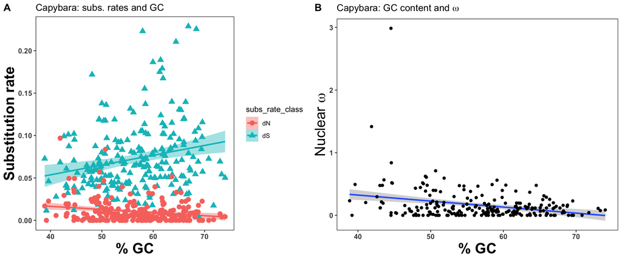

GC content explains a low fraction of substitution rate class variation in Capybara

|  | dN | dS |
| --- | --- | --- |
| Effect | -0.00036 | 0.0011 |
| R2 | 0.04 | 0.044 |
| p-value | <0.01 | <0.0001 |

This pattern is also true for the guinea pig (below), suggesting that the observed effect of GC content on substitution rates is unlikely to be an artifact of sequencing errors (although GC is only positively correlated with ds). Moreover, genomic GC content of the capybara was estimated at 39.79% and guinea pig GC content is 40.1%. Moreover, it suggests %GC alone is unlikely to be driving the observed bimodal distribution in the capybara.

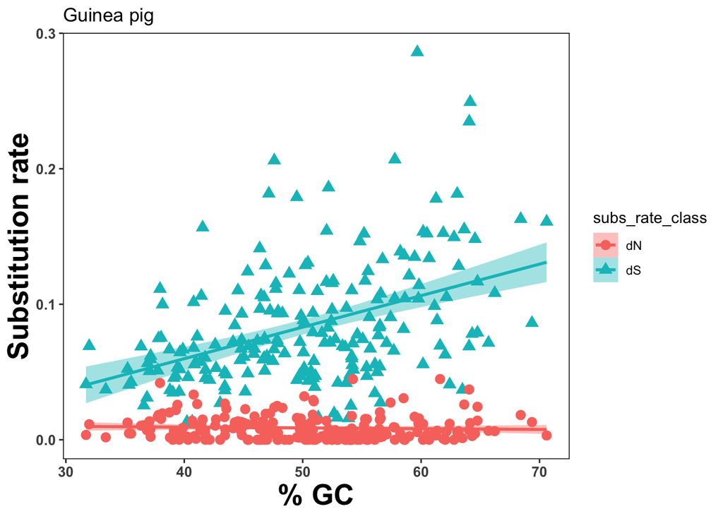

|  | dN | dS |
| --- | --- | --- |
| Effect | 0.000 | 0.0023 |
| R2 | 0.000 | 0.1835 |
| p-value | 0.457 | <0.0001 |